| title: The categorize function |
| --- |
| author: “Umut Caglar” |
| date: “2017-06-21” |
| output: rmarkdown::html_vignette |
| vignette: > |
| % |
| % |
| % |

# The categorize function

This is a document provide examples related with categorize function. It will investigate 2 examples one is related with sigmoidal and other is related with double sigmoidal

## Data generation

To make the figures, we will go backward and firstly generate some data to analyze. To add some randomness to the input data, I will use some noise. The input of all package must be in the form of a data frame with at least two columns time and intensity.

We will generate data for both sigmoidal and double sigmoidal

### Generate data for sigmoidal

```r
time=seq(3,24,0.5)

#simulate intensity data and add noise
noise_parameter=0.1
intensity_noise=stats::runif(n = length(time),min = 0,max = 1)*noise_parameter
intensity=sicegar::sigmoidalFitFormula(time, maximum=4, slopeParam=1, midPoint=8)
intensity=intensity+intensity_noise

dataInputSigmoidal=data.frame(intensity=intensity,time=time)
```

### Generate data for double - sigmoidal

```r
noise_parameter=0.2
intensity_noise=runif(n = length(time),min = 0,max = 1)*noise_parameter
intensity = sicegar::doublesigmoidalFitFormula(time,
                                               finalAsymptoteIntensityRatio=.3,
                                               maximum=4,
                                               slope1Param=1,
                                               midPoint1Param=7,
                                               slope2Param=1,
                                               midPointDistanceParam=8)
intensity=intensity+intensity_noise
dataInputDoubleSigmoidal=data.frame(intensity=intensity,time=time)
```

## Data normalization

This is the first step. Data should be normalized before any fit, i.e time and intensity should be in between 0-1 interval.

The normalization code is;

```r
normalizedSigmoidalInput = sicegar::normalizeData(dataInput = dataInputSigmoidal,
                                                  dataInputName = "sigmoidalSample")

normalizedDoubleSigmoidalInput = sicegar::normalizeData(dataInput = dataInputDoubleSigmoidal,
                                                        dataInputName = "doubleSigmoidalSample")
```

## Pre Categorize

Checks if the signal is present in the data. Often a high percentage of high through-put data does not contain a signal. Checking if data does not contain signal before doing a sigmoidal or double sigmoidal fit can make the analysis of data from high-throughput experiments much faster.

```r
preDecision_sd = sicegar::pre_categorize(normalizedInput = normalizedSigmoidalInput)
preDecision_dsd = sicegar::pre_categorize(normalizedInput = normalizedDoubleSigmoidalInput)
```

## Fits for sigmoidal and double sigmoidal

Now we need to fit all three models to the data. Linear, sigmoidal and double sigmoidal on both sigmoidal and double-sigmoidal data.

### Fit Linear, Sigmoidal and Double-Sigmoidal models to Sigmoidal data

```r
# Do the sigmoidal fit
# Fit linear model
linearModel_sd=sicegar::multipleFitFunction(dataInput=normalizedSigmoidalInput,
                                            model="linear",
                                            n_runs_min=20,
                                            n_runs_max=500,
                                            showDetails=FALSE)

# Fit sigmoidal model
sigmoidalModel_sd=sicegar::multipleFitFunction(dataInput=normalizedSigmoidalInput,
                                               model="sigmoidal",
                                               n_runs_min=20,
                                               n_runs_max=500,
                                               showDetails=FALSE)

# Fit double sigmoidal model
doubleSigmoidalModel_sd=sicegar::multipleFitFunction(dataInput=normalizedSigmoidalInput,
                                                     model="doublesigmoidal",
                                                     n_runs_min=20,
                                                     n_runs_max=500,
                                                     showDetails=FALSE)
```

### Fit Linear, Sigmoidal and Double-Sigmoidal models to Double-Sigmoidal data

```r
# Do the sigmoidal fit
# Fit linear model
linearModel_dsd=sicegar::multipleFitFunction(dataInput=normalizedDoubleSigmoidalInput,
                                             model="linear",
                                             n_runs_min=20,
                                             n_runs_max=500,
                                             showDetails=FALSE)

# Fit sigmoidal model
sigmoidalModel_dsd=sicegar::multipleFitFunction(dataInput=normalizedDoubleSigmoidalInput,
                                                model="sigmoidal",
                                                n_runs_min=20,
                                                n_runs_max=500,
                                                showDetails=FALSE)

# Fit double sigmoidal model
doubleSigmoidalModel_dsd=sicegar::multipleFitFunction(dataInput=normalizedDoubleSigmoidalInput,
                                                      model="doublesigmoidal",
                                                      n_runs_min=20,
                                                      n_runs_max=500,
                                                      showDetails=FALSE)
```

Now we will apply `sicegar::parameterCalculation` function to all sigmoidal and double sigmoidal models to generate additional variables.

```r
# Generate additional parameters for sigmoidal Data. For both sigmoidal model with sigmoidal data distribution and double sigmoidal model with sigmoidal data distribution
sigmoidalModel_sd = sicegar::parameterCalculation(sigmoidalModel_sd)
doubleSigmoidalModel_sd = sicegar::parameterCalculation(doubleSigmoidalModel_sd)


# Generate additional parameters for double sigmoidal Data. For both sigmoidal model with double sigmoidal data distribution and double sigmoidal model with double sigmoidal data distribution
sigmoidalModel_dsd = sicegar::parameterCalculation(sigmoidalModel_dsd)
doubleSigmoidalModel_dsd = sicegar::parameterCalculation(doubleSigmoidalModel_dsd)
```

## Generate figures

Here are the two datasets that we want to categorize:

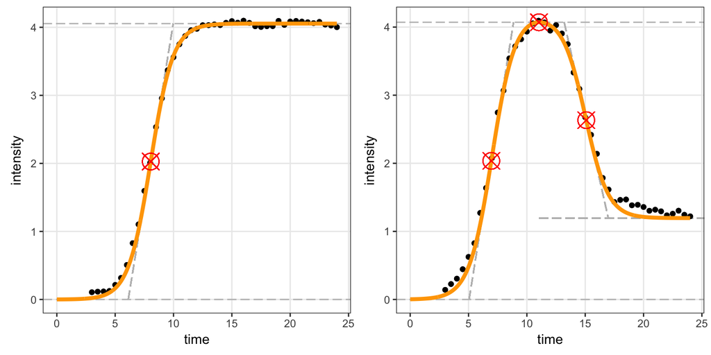

```r
fig03a=sicegar::figureModelCurves(dataInput=normalizedSigmoidalInput,
                                  sigmoidalFitVector=sigmoidalModel_sd,
                                  showParameterRelatedLines=TRUE)
#print(fig03a)

# Double Sigmoidal Fit with parameter related lines
fig03b=sicegar::figureModelCurves(dataInput=normalizedDoubleSigmoidalInput,
                                  doubleSigmoidalFitVector=doubleSigmoidalModel_dsd,
                                  showParameterRelatedLines=TRUE)
#print(fig03b)

fig03 <- cowplot::plot_grid(fig03a, fig03b, ncol = 2)
print(fig03)
```

## Model decision

Now we have attempts of fits for sigmoidal and double sigmoidal models on our datasets. By using the results of those attempts, one can make decisions about the category of the input data; whether it is sigmoidal or double sigmoidal. Here we mention three thresholds explicitly since their values strictly depend on the data source and measurement device properties.

```r
outputCluster_sd=sicegar::categorize(threshold_minimum_for_intensity_maximum = 0.3,
                                     threshold_intensity_range = 0.1,
                                     threshold_t0_max_int = 0.05,
                                     parameterVectorSigmoidal=sigmoidalModel_sd,
                                     parameterVectorDoubleSigmoidal=doubleSigmoidalModel_sd)

utils::str(outputCluster_sd) # This should give sigmoidal
```

```
## List of 40
##  $ test.name                               : logi TRUE
##  $ dataInputName                           : chr "sigmoidalSample"
##  $ test.sm_modelCheck                      : logi TRUE
##  $ test.dsm_modelCheck                     : logi TRUE
##  $ test.dataScalingParameters              : logi TRUE
##  $ intensityMaximum                        : num 4.1
##  $ threshold_minimum_for_intensity_maximum : num 0.3
##  $ test.minimum_for_intensity_maximum      : logi TRUE
##  $ intensityRange                          : num 3.99
##  $ threshold_intensity_range               : num 0.1
##  $ test.intensity_range                    : logi TRUE
##  $ test.sigmoidalFit                       : logi TRUE
##  $ test.doublesigmoidalFit                 : logi TRUE
##  $ test.sigmoidalAdditionalParameters      : logi TRUE
```

[output cut: 26 more lines]

```r
outputCluster_dsd=sicegar::categorize(threshold_minimum_for_intensity_maximum = 0.3,
                                      threshold_intensity_range = 0.1,
                                      threshold_t0_max_int = 0.05,
                                      parameterVectorSigmoidal=sigmoidalModel_dsd,
                                      parameterVectorDoubleSigmoidal=doubleSigmoidalModel_dsd)

utils::str(outputCluster_dsd) # This should give double-sigmoidal
```

```
## List of 40
##  $ test.name                               : logi TRUE
##  $ dataInputName                           : chr "doubleSigmoidalSample"
##  $ test.sm_modelCheck                      : logi TRUE
##  $ test.dsm_modelCheck                     : logi TRUE
##  $ test.dataScalingParameters              : logi TRUE
##  $ intensityMaximum                        : num 4.09
##  $ threshold_minimum_for_intensity_maximum : num 0.3
##  $ test.minimum_for_intensity_maximum      : logi TRUE
##  $ intensityRange                          : num 3.95
##  $ threshold_intensity_range               : num 0.1
##  $ test.intensity_range                    : logi TRUE
##  $ test.sigmoidalFit                       : logi TRUE
##  $ test.doublesigmoidalFit                 : logi TRUE
##  $ test.sigmoidalAdditionalParameters      : logi TRUE
```

[output cut: 26 more lines]

## The Decision Process

The decision process composes mainly two parts. The first one is pre-test process that controls if everything provided is useful and fits to each_other. If one calls the main function and the main function calls the `sicegar::categorize()`, then the pre_check steps do not matter, because the data processed through the pipeline provided by the main function indeed pass the pre_test. The steps of pre_test are;

- Pre-test0: The pre_test algorithm checks, If the function was provided sigmoidal and double_sigmoidal models.
- Pre-test1: The pre_test algorithm checks, If the provided sigmoidal and double sigmoidal models come from the same source and have the same data name.
- Pre-test2a: The pre_test algorithm checks, If the provided sigmoidal model is generated by `sicegar::sigmoidalFitFunctions`.
- Pre-test2b: The pre_test algorithm checks, If the provided double_sigmoidal model is generated by `sicegar::doublesigmoidalFitFunctions`.
- Pre-test3: The pre_test algorithm checks, If both models have same scaling parameters related with data normalization process.
- Pre-test4a: The pre_test algorithm checks, If the additional parameters for sigmoidal fit are calculated by `sicegar::parameterCalculation()`.
- Pre-test4b: The pre_test algorithm checks, If the additional parameters for double-sigmoidal fit are calculated by `sicegar::parameterCalculation()`.

After the pre_test step, the primary decision process starts with generating the choices vector. `choices = c("no_signal", "sigmoidal", "double_sigmoidal", "ambiguous")`

The following procedure deletes the “not possible options” from the vector until only one option left.

Firstly in step one, the algorithm checks if the provided data includes a signal or not.

- Test 1a: Observed intensity maximum must be bigger than `threshold_minimum_for_intensity_maximum`; otherwise, the data is labeled with “no_signal”.
- Test 1b: The absolute difference between two parameters `intensity_max`, and `intensity_min`, i.e., the intensity range must be greater than `threshold_intensity_range`; otherwise, the data is labeled with “no_signal”.
- Test 1c: If at this point the data is not labeled with `"no_signal"`; then the data can not be labeled with `"no signal"` anymore.

Then the algorithm checks if the sigmoidal and double sigmoidal models make sense in steps two to seven.

- Test 2a: Provided sigmoidal fit must be a successful fit; otherwise, the data can not be labeled with `"sigmoidal"`.
- Test 2b: Provided double sigmoidal fit must be a successful fit; otherwise, the data can not labelled with `"double_sigmoidal"`.
- Test 3a: The sigmoidal fit must have an AIC score smaller than `threshold_AIC`; otherwise, the data can not be labeled with `"sigmoidal"`.
- Test 3b: Double sigmoidal fit must have an AIC score smaller than `threshold_AIC`; otherwise, the data can not be labeled with `"double_sigmoidal"`.
- Test 4a: Sigmoidal models `startPoint_x` must be a positive number; otherwise, the data can not be labeled with `"sigmoidal"`.
- Test 4b: Double-sigmoidal models `startPoint_x` must be a positive number; otherwise, the data can not be labeled with `"double_sigmoidal"`.
- Test 5a: Sigmoidal models `start_intensity`, i.e. the intensity at t=0, must be smaller than `threshold_t0_max_int`; otherwise, the data can not be labeled with `"sigmoidal"`.
- Test 5b: Double sigmoidal models `start_intensity`, i.e. the intensity at t=0, must be smaller than `threshold_t0_max_int`; otherwise, the data can not be labeled with `"double_sigmoidal"`.
- Test 6: For the double sigmoidal model; the ratio of */models intensity prediction at last observation time/* to */the models maximum intesity prediction/* must be smaller than `threshold_dsm_tmax_IntensityRatio`; otherwise, the data can not be labeled with `"double_sigmoidal"`.
- Test7: For the sigmoidal model; the ratio of */models intensity prediction at last observation time/* to */the models maximum intesity prediction/* must be smaller than `threshold_sm_tmax_IntensityRatio`; otherwise, the data can not be labeled with `"sigmoidal"`.

In the step eight, the algorithm checks wheather the data should be labelled as `"ambiguous"` or not.

- Test 8: If at this point we still have at least one of `"sigmoidal"` or `"double_sigmoidal"` options, then the data can not be labeled with `"ambiguous"`.

In the last part; the algorithm checks whether the data should be labeled as `"sigmoidal"` or `"double_sigmoidal"`.

- Test 9: Now if at this point we still have both “sigmoidal” and “double_sigmoidal” options, then the choice will be made based on AIC scores of those models and `threshold_bonus_sigmoidal_AIC`.

The smaller side of the equation will be chosen as the decision. If `sigmoidalAIC + threshold_bonus_sigmoidal_AIC < doublesigmoidalAIC`, then the data can not be labeled with `"double_sigmoidal"` and if `sigmoidalAIC + threshold_bonus_sigmoidal_AIC > doublesigmoidalAIC`, then the data can not be labeled with `"sigmoidal"`.

The only option that is left at this point will be the label of the data.